# Introduction

#### Mingxin Ye

# Tutorial Content:

- Introduction
- data curation, parsing, and management
- Exploratory Data analysis
- Hypothesis Testing
- Machine Learning
- Conclusion

# Data curation, Parsing, and Management:

In many cases, the dataset you are given are either very messy and hard to read, or not in a user-friendly format that is easy to analysis with. Therefore, tidy data is very important as the preperation of a dataset. Tidy data is an concept that developed by Hadley Wickham that gives people guideline of how to make data cleaning as easy and effective as possible. Here I already found a dataset that is in the format of csv which doesn't have to parsed in this case. In many other stuations, we would have to parse the data from html/text formmat to a format that are easy to use like sql or csv.

Before starting to import data, we need to install library: To utilize all the data analysis tools and resources, we need to install proper libraries and documentations. Pandas is a software library written for the Python programming language for data manipulation and analysis and Numpy is the fundamental package for scientific computing with Python.

```python
%matplotlib inline
import pandas as pd
import numpy as np
import matplotlib as mpl
import matplotlib.pyplot as plt
import seaborn as sns
import statsmodels.api as sm
from bs4 import BeautifulSoup
from scipy import stats
from statsmodels.formula.api import ols
from sklearn.linear_model import LinearRegression
from sklearn.feature_selection import f_regression
```

First import data into the notebook using pandas. Here I chose a dataset of information about all the university in united states in the year of 2015

```python
Colleges = pd.read_csv("MERGED2015_16_PP.csv")

#Next, I dropped columns that are not needed and left the useful ones here
Colleges = Colleges[['INSTNM','CONTROL','ADM_RATE','SATVR25','SATVR75','SATMT25','SATMT75','SATWR25','SATWR75', 'ACTCM25', 'ACTCM75','ACTCMMID', 'ACTWR25', 'ACTWR75','ACTWRMID','ACTEN25','ACTEN75','ACTENMID', 'SAT_AVG']]

#1 = Public
#2 = Private Nonprofit
#3 = Private For-Profit

Colleges.head()
```

|  | INSTNM | CONTROL | ADM_RATE | SATVR25 | SATVR75 | SATMT25 | SATMT75 | SATWR25 | SATWR75 | ACTCM25 | ACTCM75 | ACTCMMID | ACTWR25 | ACTWR75 | ACTWRMID | ACTEN25 | ACTEN75 | ACTENMID | SAT_AVG |
| --- | --- | --- | --- | --- | --- | --- | --- | --- | --- | --- | --- | --- | --- | --- | --- | --- | --- | --- | --- |
| 0 | Alabama A & M University | 1 | 0.6538 | 383.0 | 470.0 | 360.0 | 480.0 | 370.0 | 457.0 | 16.0 | 19.0 | 18.0 | NaN | NaN | NaN | 14.0 | 20.0 | 17.0 | 850.0 |
| 1 | University of Alabama at Birmingham | 1 | 0.6043 | 520.0 | 630.0 | 520.0 | 668.0 | NaN | NaN | 22.0 | 28.0 | 25.0 | NaN | NaN | NaN | 22.0 | 30.0 | 26.0 | 1147.0 |
| 2 | Amridge University | 2 | NaN | NaN | NaN | NaN | NaN | NaN | NaN | NaN | NaN | NaN | NaN | NaN | NaN | NaN | NaN | NaN | NaN |
| 3 | University of Alabama in Huntsville | 1 | 0.8120 | 520.0 | 650.0 | 550.0 | 680.0 | NaN | NaN | 24.0 | 30.0 | 27.0 | NaN | NaN | NaN | 24.0 | 32.0 | 28.0 | 1221.0 |
| 4 | Alabama State University | 1 | 0.4639 | 370.0 | 450.0 | 360.0 | 460.0 | NaN | NaN | 16.0 | 19.0 | 18.0 | NaN | NaN | NaN | 14.0 | 19.0 | 17.0 | 844.0 |

To demonstrate one type of parsing in data extraction, I decided to get dataset of the first 1000 universities in the world that is ranked by CWUR. To match the dataset above, I used the ranking for 2015.

```python
page = open("CWUR 2015 _ Top Universities in the USA.html","r")

#convert the data to text form
#data = page.text

#use beautifulSoup to convert data to html format
soup = BeautifulSoup(data,"html.parser")

#find the table in html page
table = soup.find('table')

#use pandads to form a dataframe with the table
ranking = pd.read_html(str(table), flavor = 'bs4')[0]

ranking.head()
```

|  | World Rank | Institution | Location | National Rank | Quality of Education | Alumni Employment | Quality of Faculty | Publications | Influence | Citations | Broad Impact | Patents | Score |
| --- | --- | --- | --- | --- | --- | --- | --- | --- | --- | --- | --- | --- | --- |
| 0 | 1 | Harvard University | USA | 1 | 1 | 1 | 1 | 1 | 1 | 1 | 1 | 3 | 100.00 |
| 1 | 2 | Stanford University | USA | 2 | 9 | 2 | 4 | 5 | 3 | 3 | 4 | 10 | 98.66 |
| 2 | 3 | Massachusetts Institute of Technology | USA | 3 | 3 | 11 | 2 | 15 | 2 | 2 | 2 | 1 | 97.54 |
| 3 | 4 | University of Cambridge | United Kingdom | 1 | 2 | 10 | 5 | 11 | 6 | 12 | 13 | 48 | 96.81 |
| 4 | 5 | University of Oxford | United Kingdom | 2 | 7 | 13 | 10 | 7 | 12 | 7 | 9 | 15 | 96.46 |

```python
ranking_USA = ranking[ranking['Location']=='USA']
ranking_USA = ranking_USA[['Institution','National Rank']]
ranking_USA.head()
```

|  | Institution | National Rank |
| --- | --- | --- |
| 0 | Harvard University | 1 |
| 1 | Stanford University | 2 |
| 2 | Massachusetts Institute of Technology | 3 |
| 5 | Columbia University | 4 |
| 6 | University of California, Berkeley | 5 |

# Exploratory Data analysis:

Now we have two usuable dataset, we will move forward to see if there is any patterns we can find in the dataset. Looking at the first table, I'm interested to see if there is any direct relationship between the admission rate and the average SAT score of the school. I first plot the relationship with the entire dataset. Below is the result.

### Does lower admission rate means a higher average test score?

#### Admission Rate vs. SAT Score:

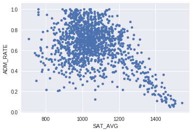

```python
Colleges.plot(y = 'ADM_RATE', x = 'SAT_AVG', kind = 'scatter')
plt.show()
```

With this large amount of data, it is hard to tell whether there is a direct relationship between the average SAT score and the admission rate. Especially when the average SAT score is between 800 to 1200, the relationship seems to be random and not directly dependent on each other. However on the other side, we notice that there is a decreasing tendency when the average sat for the university go over 1200(which is usually considered as a selective/competitive score). Therefore, we decided to narrow down our data set and make a new plot with average sat scores that are higher than 1200.

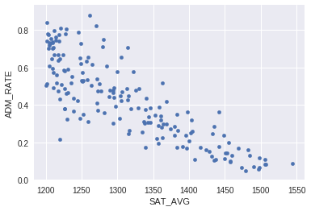

```python
High_SAT_AVG = Colleges[Colleges['SAT_AVG'] > 1200]

High_SAT_AVG.plot(y = 'ADM_RATE', x = 'SAT_AVG', kind = 'scatter')

plt.show()
```

With the graph above we can see a tendency that the lower the admission rate is the higher the average SAT score tends to be. Now we have some results for average SAT score, we are also interested in ACT score.

#### Admission Rate vs. ACT Score:

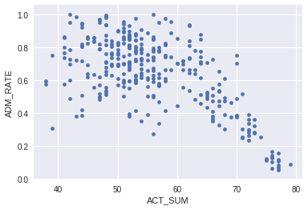

```python
Colleges['ACT_SUM'] = Colleges['ACTCMMID'] + Colleges['ACTWRMID'] + Colleges['ACTENMID']

Colleges.plot(y = 'ADM_RATE', x = 'ACT_SUM', kind = 'scatter')
plt.show()
```

Interestingly with the graph above we observed a similar tendency that, with the large amount of school range, the relationship between ACT midpoint score and admission rate seems to be random and not directly dependent on each other. We also notice, above score 60, the plot starts to have a decreasing tendencyp, so we decided to make a new plot with the smaller dataset.

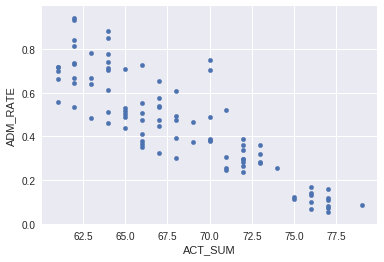

```python
High_ACT_MID = Colleges[Colleges['ACT_SUM'] > 60]

High_ACT_MID.plot(y = 'ADM_RATE', x = 'ACT_SUM', kind = 'scatter')

plt.show()
```

With the plot above, we observed that there is a trend that the lower the admission rate is, the higher the ACT midpoint score tends to be when the ACT midpoint score is higher than 60.

Now we found a possible pattern when average SAT is above 1200 and ACT midpoint score is above 60, but not one when scores are out of those two ranges. Therefore, we wonder wether there is another factor that can come into play. I want to figure out whether it will make a difference between public schools and private schools. Therefore, I seperate data according to school type. The result is below.

#### Does school type(public/private nonprofit/private for-profit) plays a part in this?

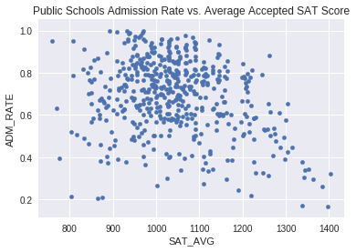

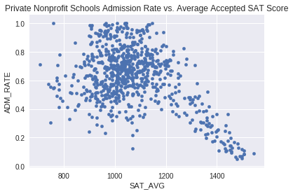

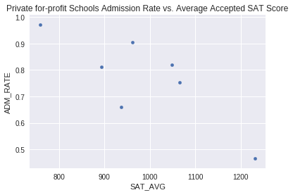

```python
school_type = [1, 2, 3]

for i in school_type:
    Colleges_by_type = Colleges.groupby(['CONTROL']).get_group(i)
    Colleges_by_type.plot(y = 'ADM_RATE', x = 'SAT_AVG', kind = 'scatter')
    if i == 1:
        plt.title("Public Schools Admission Rate vs. Average Accepted SAT Score")
    elif i == 2:
        plt.title("Private Nonprofit Schools Admission Rate vs. Average Accepted SAT Score")
    elif i == 3:
        plt.title("Private for-profit Schools Admission Rate vs. Average Accepted SAT Score")
plt.show()
```

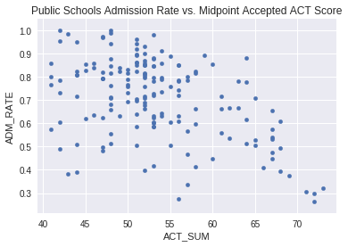

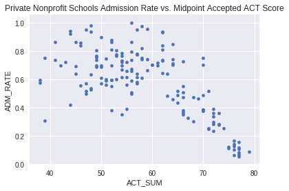

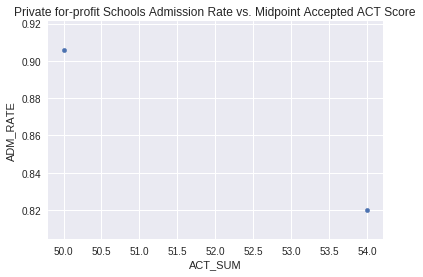

```python
school_type = [1, 2, 3]

for i in school_type:
    Colleges_by_type = Colleges.groupby(['CONTROL']).get_group(i)
    Colleges_by_type.plot(y = 'ADM_RATE', x = 'ACT_SUM', kind = 'scatter')
    if i == 1:
        plt.title("Public Schools Admission Rate vs. Midpoint Accepted ACT Score")
    elif i == 2 :
        plt.title("Private Nonprofit Schools Admission Rate vs. Midpoint Accepted ACT Score")
    elif i == 3:
        plt.title("Private for-profit Schools Admission Rate vs. Midpoint Accepted ACT Score")
plt.show()
```

From the data above, we can't find a definite correlation between admission rate and Standard Test Score, but the overall trend is decreasing. With few data, we can't predict results for private for-profit schools. However, on the bright side, we did observe a more obvious decreasing trend in admission rate as the test score goes up for private non-profit schools. Which makes it more predicable for two people with same standard test score to get into a private school than a public school.

### Linear Regression

Below are two examples of how to fit a linear regressions using the data above

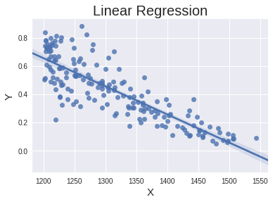

```python
sns.regplot(y = 'ADM_RATE', x = 'SAT_AVG', data=High_SAT_AVG)
plt.title('Linear Regression', fontsize = 20)
plt.xlabel('X', fontsize = 15)
plt.ylabel('Y', fontsize = 15)
plt.show()
```

```python
result = ols(formula="ADM_RATE ~ SAT_AVG", data=High_SAT_AVG).fit()
print (result.summary())
```

```
                            OLS Regression Results
==============================================================================
Dep. Variable:               ADM_RATE   R-squared:                       0.711
Model:                            OLS   Adj. R-squared:                  0.710
Method:                 Least Squares   F-statistic:                     426.0
Date:                Sat, 16 Dec 2017   Prob (F-statistic):           1.58e-48
Time:                        18:23:47   Log-Likelihood:                 129.59
No. Observations:                 175   AIC:                            -255.2
Df Residuals:                     173   BIC:                            -248.8
Df Model:                           1
Covariance Type:            nonrobust
==============================================================================
                 coef    std err          t      P>|t|      [0.025      0.975]
------------------------------------------------------------------------------
Intercept      3.0503      0.127     23.944      0.000       2.799       3.302
SAT_AVG       -0.0020   9.67e-05    -20.640      0.000      -0.002      -0.002
==============================================================================
Omnibus:                        2.703   Durbin-Watson:                   1.574
Prob(Omnibus):                  0.259   Jarque-Bera (JB):                2.761
Skew:                           0.041   Prob(JB):                        0.251
Kurtosis:                       3.610   Cond. No.                     1.91e+04
==============================================================================

Warnings:
[1] Standard Errors assume that the covariance matrix of the errors is correctly specified.
[2] The condition number is large, 1.91e+04. This might indicate that there are
strong multicollinearity or other numerical problems.
```

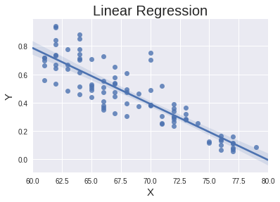

```python
sns.regplot(y = 'ADM_RATE', x = 'ACT_SUM', data=High_ACT_MID)
plt.title('Linear Regression', fontsize = 20)
plt.xlabel('X', fontsize = 15)
plt.ylabel('Y', fontsize = 15)
plt.show()
```

```python
result = ols(formula="ADM_RATE ~ ACT_SUM", data=High_ACT_MID).fit()
print (result.summary())
```

```
                            OLS Regression Results
==============================================================================
Dep. Variable:               ADM_RATE   R-squared:                       0.752
Model:                            OLS   Adj. R-squared:                  0.750
Method:                 Least Squares   F-statistic:                     273.5
Date:                Sat, 16 Dec 2017   Prob (F-statistic):           5.03e-29
Time:                        18:23:47   Log-Likelihood:                 70.391
No. Observations:                  92   AIC:                            -136.8
Df Residuals:                      90   BIC:                            -131.7
Df Model:                           1
Covariance Type:            nonrobust
==============================================================================
                 coef    std err          t      P>|t|      [0.025      0.975]
------------------------------------------------------------------------------
Intercept      3.1665      0.164     19.318      0.000       2.841       3.492
ACT_SUM       -0.0397      0.002    -16.538      0.000      -0.044      -0.035
==============================================================================
Omnibus:                        9.272   Durbin-Watson:                   1.943
Prob(Omnibus):                  0.010   Jarque-Bera (JB):                9.046
Skew:                           0.690   Prob(JB):                       0.0109
Kurtosis:                       3.676   Cond. No.                         944.
==============================================================================

Warnings:
[1] Standard Errors assume that the covariance matrix of the errors is correctly specified.
```

As it shows above, there is clearly a decreasing trend in admission rate as the school's average accepted SAT goes up, as you can see the coefficient is negative for both plots.

# Hypothesis Testing:

What is Hypothesis Testing? a hypothesis that is testable on the basis of observing a process that is modeled via a set of randomvariables.

https://en.wikipedia.org/wiki/Statistical_hypothesis_testing

Steps to Hypothesis Testing:

- Find a Null Hypothesis. It's usually the opposite of your alternative hypothesis
- state your Null Hypothesis
- Find a test to test your Hypothesis
- Use the result to either reject Null Hypothesis(accept alternative hypothesis) or accept Null Hypothesis

Examples for Hypothesis Testing: Here is the linking to a example of Statistic Hypothesis Testing using statsmodal imported from scipy: http://knowledgetack.com/python/statsmodels/two-sample-hypothesis-testing-in-python-with-statsmodels/

# Machine Learning:

### Four majors way to implement Machine learning:

- K-Nearest Neighbors
- Gradient Descent
- Decision Trees
- Random Forests

#### Decision Trees

Decision Trees is a sequence of tests that very closly representation human nature of making a decisions. There are couple things needed to get it started. They are:

- a set of undecided data
- a function h that take in data as an entry
- the out put of the function will be a decision

##### There are two type of notes in a decision trees:

Decision node:

- it is the node that specify a choice or test of some attribute with 2 or more alternatives
- every decision node is part of a path to a leaf node Leaf node:
- Leaf node are usually at the bottom of the tree and they serve as a classification of an example

#### K-Nearest Neighbors

K-Nearest Neighbors is another very funtional maching learning method.There are three things required for this method. They are:

- A set of stored record
- Distance Metricto compute distance between records
- The value of k,which is the number of nearest neighbors to retrieve

You start by finding the nearest neighbors(unknown data) to the known data(stored record) with a metric system. Then you will classify the known data with the known data. Hence unknown data become known data, so we can use those new known data to find their closest neighbours to countinue the algrorithm.

#### Gradient Descent

```python
#Problem 3 Implement the gradient descent algorithm (either batch or stochastic versions)
#for multiple logistic regression. I.e., modify your code in problem 1 for the logistic regression update equation.

#Make sure you include in your submission writeup,
#which version of the algorithm you are solving (stochastic or batch),
#and make sure to comment your code to help us understand your implementation.

# Training data (X, y), T time steps, alpha step
def grad_descent_logreg(X, y, T, alpha):
    m, n = X.shape # m = #examples, n = #features
    theta = np.zeros(n)    # initialize parameters
    f = np.zeros(T)        # track loss over time
    for i in range(T):
        h = np.exp(X.dot(theta))/(1+np.exp(X.dot(theta)))
        # loss for current parameter vector theta
        f[i] = np.log2(1+np.exp(h.dot(y)))
        # compute steepest ascent at f(theta)
        g = (y-h).dot(X)
        # step down the gradient
        theta = theta - alpha*g
    return theta, f
```

# Conclusion

This tutorial had coverd basics in Data science and machine learnings. We have talked about data scraping and parsing, Data analysis including tidy data, Hypothesis Testing and three out of four algrithom of Machine Learning.Data science is a board subject. There are much more beyound what is included here. Luckily there are many online resourses that can provide more insights to the subjects. I hope you had learned something from this tutorial. Thank you!